# Simple Linear Regression

```r
# Load your libraries
library(car)
library(tidyverse)
library(mosaic)
library(DT)
library(pander)
library(ggplot2)
library(readr)
SP <- read_csv("../../SleepPurchasesOCT21.csv")

# Load your data after saving a csv file in your Data folder.
# You can use either
#   someName <- read.csv("../Data/YourDataFileName.csv", header=TRUE)
# or
#   library(readr)
#   someName <- read_csv("../Data/YourDataFileName.csv")

# Don't forget to run "Session -> Set Working Directory -> To Source file location"
```

## Background

I collected data from my phone on sleep times from the last 30 days. This was gathered as time to bed and time to waking up. I then calculated from these the total number of minutes slept and then calculated a small rolling average of the current day and the previous. Finally I collected data from my back account on all of my purchases from the previous 30 days, I excluded all expenses that were planned, such as my normal spending on groceries, purchasing of housing, subscriptions, etc. as these are expenses I know are not related to sleep and are independent of my other spending habits.

I wanted to test if any relation at all existed between how much sleep I had gotten and how much money I spent so a basic linear regression seems suffecient for these two variables. The model used and hypotheses used for my test are below.

The true regression model assumed by a regression analysis is given by

$$\underbrace{Y_i}_\text{Non-Planned Spending} = \overbrace{\beta_0}^\text{y-int} + \overbrace{\beta_1}^\text{slope} \underbrace{X_i}_\text{2-day running Avg Sleep} + \epsilon_i \quad \text{where} \ \epsilon_i \sim N(0, \sigma^2)$$

Our Hypotheses are as follows:
$$\left.\begin{array}{ll}
H_0: \beta_1 = 0 \\
H_a: \beta_1 \neq 0
\end{array}
\right\} \ \text{Slope Hypotheses}$$

$$\alpha = 0.05$$

### Regression Test

Here are the results of the regression analysis, as shown, our results provided a probability of p=0.4471, and an adjusted r^2 = -0.03517. Note that the sample size is only 12, I was only able to access data on my sleep for the previous 30 days and had only made unplanned purchases on 12 of those days, leaving me with a relatively small sample size.

```r
SP$SleepTimeHours <- SP$Running_Avg / 60
```

```r
mylm <- lm(`Non-Planned Expenses` ~ SleepTimeHours, data = SP)
summary(mylm) %>%
pander(caption = "Simple Regression Model")
```

|  | Estimate | Std. Error | t value | Pr(>\|t\|) |
| --- | --- | --- | --- | --- |
| **(Intercept)** | 82.68 | 67.01 | 1.234 | 0.2455 |
| **SleepTimeHours** | -8.023 | 10.14 | -0.7914 | 0.4471 |

Simple Regression Model

| Observations | Residual Std. Error | $R^2$ | Adjusted $R^2$ |
| --- | --- | --- | --- |
| 12 | 23.24 | 0.05894 | -0.03517 |

### Regression Model

Here is the regression model provided by this test, despite the non-significant P-Value we will continue to graph and visualize the implications of this in an attempt to better understand the significance of our data.

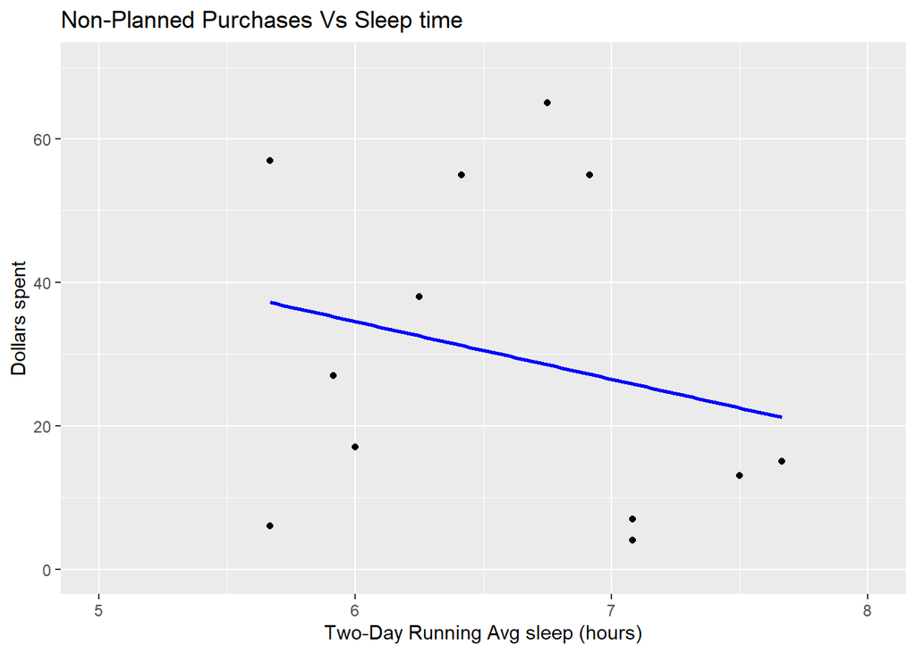

```r
#plot(`Non-Planned Expenses`~ Running_Avg, data= SP)
ggplot(SP, aes(x = SP$Running_Avg /60 , y =SP$`Non-Planned Expenses`)) +
  geom_point() +
  geom_smooth(method = "lm", formula = y~x, se = FALSE, size = 1, color = "blue1",
  linetype = "solid")+
  labs(title="Non-Planned Purchases Vs Sleep time", x="Two-Day Running Avg sleep (hours)", y="Dollars spent")+
coord_cartesian(xlim = c(5, 8),ylim = c(0,70))
```

### Assumptions

The Residuals vs Fitted values shows a significant curvature suggesting the probability of a non-linear relationship or that our variance in non-constant.

The Q-Q plot seems relatively normal, our values tend to remain close but we can observe a repeating diagonal pattern that may be interesting to look further into.

Lastly the Residuals vs Order is (finally) relatively random, showing that the order of our data does not appear to be of consequence. This is of particular importance for my data set as it is ordered from top to bottom by date, the presence of a pattern here would suggest that time was also a factor in my spending.

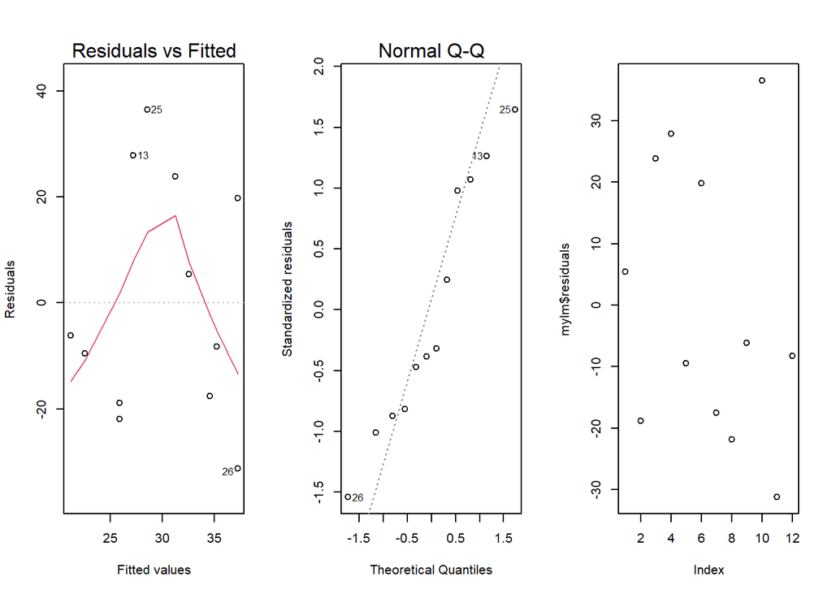

```r
par(mfrow=c(1,3))
plot(mylm,which=1:2)
plot(mylm$residuals)
```

### Condfidence Interval

These help the illustrate that the P-value is so insignificant that we cannot even predict with relative confidence whether the relationship is positive or negative, or even that a relationship exists in the first place.

```r
confint(mylm, level = .95) %>%
pander(caption = "95% Confidence interval")
```

95% Confidence interval

|  | 2.5 % | 97.5 % |
| --- | --- | --- |
| **(Intercept)** | -66.62 | 232 |
| **SleepTimeHours** | -30.61 | 14.57 |

Note that 0 is contained within the given interval, The significance of this is explained in greater depth in the conclusion tab.

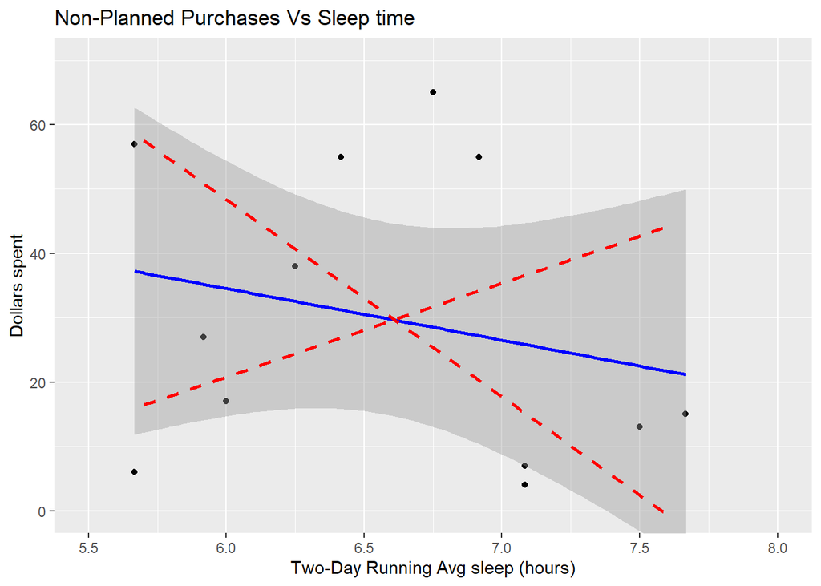

```r
fun.1 <- function(x) 14.57*x + -66.62
fun.2 <- function(x) -30.61*x + 232
ggplot(SP, aes(x = SP$Running_Avg /60 , y =SP$`Non-Planned Expenses`)) +
  geom_point() +
  geom_smooth(method = "lm", formula = y~x, se = TRUE, size = 1, color = "blue1",
  linetype = "solid")+
   stat_function(fun = "fun.1", size = 1, color = "red1", xlim= c(5.7,7.6),
  linetype = "dashed")+
  stat_function(fun = "fun.2", size = 1, color = "red1", xlim= c(5.7,7.6),
  linetype = "dashed")+
  labs(title="Non-Planned Purchases Vs Sleep time", x="Two-Day Running Avg sleep (hours)", y="Dollars spent")+
  coord_cartesian(xlim = c(5.5, 8),ylim = c(0,70))
```

### Conclusion

Our model does show that if a relationship did exist, based on our sample it is somewhat more likely to be negative than positive. Regardless given our model’s probability is so high, the questionable patterns found in our Q-Q plot, Fitted-Residuals, and the fact that our confidence interval straddles 0, we will fail to reject the null hypothesis, It does not appear that any relationship is present within our data given our sample and results.

As shown by the confidence interval of our regression model, our slope could be potentially at the 95% confidence level either a negative or positive value, which when averaged in a sense leaves us with 0, it is in essence the same as a dead slope, showing us that the presence of a definitive relationship is unlikely.

### Data

```r
datatable(SP)
```

|  | Date | To_Bed | Date_1 | Wake_up | Sleep | Sleep_char | Hours | Min | Total_Min | Running_Avg | Non-Planned Expenses | SleepTimeHours |
| --- | --- | --- | --- | --- | --- | --- | --- | --- | --- | --- | --- | --- |
| 1 | 3-Oct | 04:10:00 | 3-Oct | 10:20:00 | 06:10:00 | 6.1 | 6 | 10 | 370 | 370 |  | 6.16666666666667 |
| 2 | 4-Oct | 01:40:00 | 4-Oct | 08:00:00 | 06:20:00 | 6.2 | 6 | 20 | 380 | 375 | 38 | 6.25 |
| 3 | 5-Oct | 00:30:00 | 5-Oct | 08:20:00 | 07:50:00 | 7.5 | 7 | 50 | 470 | 425 | 7 | 7.08333333333333 |
| 4 | 6-Oct | 02:20:00 | 6-Oct | 07:20:00 | 05:00:00 | 5 | 5 | 00 | 300 | 385 | 55 | 6.41666666666667 |
| 5 | 7-Oct | 00:30:00 | 7-Oct | 07:40:00 | 07:10:00 | 7.1 | 7 | 10 | 430 | 365 |  | 6.08333333333333 |
| 6 | 8-Oct | 03:30:00 | 8-Oct | 08:50:00 | 05:20:00 | 5.2 | 5 | 20 | 320 | 375 |  | 6.25 |
| 7 | 9-Oct | 02:40:00 | 9-Oct | 11:20:00 | 08:40:00 | 8.4 | 8 | 40 | 520 | 420 |  | 7 |
| 8 | 10-Oct | 03:20:00 | 10-Oct | 08:30:00 | 05:10:00 | 5.1 | 5 | 10 | 310 | 415 |  | 6.91666666666667 |
| 9 | 11-Oct | 00:00:00 | 11-Oct | 08:00:00 | 08:00:00 | 8 | 8 | 00 | 480 | 395 |  | 6.58333333333333 |
| 10 | 12-Oct | 00:50:00 | 12-Oct | 07:20:00 | 06:30:00 | 6.3 | 6 | 30 | 390 | 435 |  | 7.25 |

[output cut: 22 more lines]